# Makeup & Beauty Product Analysis

This notebook analyzes a makeup/beauty product dataset to understand pricing, customer satisfaction, and engagement across brands and categories. The goal is to answer 10 analytical questions with clear visuals.

## 1. Introduction

We explore a product catalog with ratings, prices, reviews, and popularity signals. The objective is to identify customer satisfaction drivers and pricing/engagement patterns for better product and marketing decisions.

## 2. Load data

```python
import pandas as pd
import numpy as np
import matplotlib.pyplot as plt
import seaborn as sns

sns.set_theme(style="whitegrid")

DATA_PATH = "product_info.csv"
df_raw = pd.read_csv(DATA_PATH)
df_raw.head()
```

|  | product_id | product_name | brand_id | brand_name | loves_count | rating | reviews | size | variation_type | variation_value | ... | online_only | out_of_stock | sephora_exclusive | highlights | primary_category | secondary_category | tertiary_category | child_count | child_max_price | child_min_price |
| --- | --- | --- | --- | --- | --- | --- | --- | --- | --- | --- | --- | --- | --- | --- | --- | --- | --- | --- | --- | --- | --- |
| 0 | P473671 | Fragrance Discovery Set | 6342 | 19-69 | 6320 | 3.6364 | 11.0 | NaN | NaN | NaN | ... | 1 | 0 | 0 | ['Unisex/ Genderless Scent', 'Warm &Spicy Scen... | Fragrance | Value & Gift Sets | Perfume Gift Sets | 0 | NaN | NaN |
| 1 | P473668 | La Habana Eau de Parfum | 6342 | 19-69 | 3827 | 4.1538 | 13.0 | 3.4 oz/ 100 mL | Size + Concentration + Formulation | 3.4 oz/ 100 mL | ... | 1 | 0 | 0 | ['Unisex/ Genderless Scent', 'Layerable Scent'... | Fragrance | Women | Perfume | 2 | 85.0 | 30.0 |
| 2 | P473662 | Rainbow Bar Eau de Parfum | 6342 | 19-69 | 3253 | 4.2500 | 16.0 | 3.4 oz/ 100 mL | Size + Concentration + Formulation | 3.4 oz/ 100 mL | ... | 1 | 0 | 0 | ['Unisex/ Genderless Scent', 'Layerable Scent'... | Fragrance | Women | Perfume | 2 | 75.0 | 30.0 |
| 3 | P473660 | Kasbah Eau de Parfum | 6342 | 19-69 | 3018 | 4.4762 | 21.0 | 3.4 oz/ 100 mL | Size + Concentration + Formulation | 3.4 oz/ 100 mL | ... | 1 | 0 | 0 | ['Unisex/ Genderless Scent', 'Layerable Scent'... | Fragrance | Women | Perfume | 2 | 75.0 | 30.0 |
| 4 | P473658 | Purple Haze Eau de Parfum | 6342 | 19-69 | 2691 | 3.2308 | 13.0 | 3.4 oz/ 100 mL | Size + Concentration + Formulation | 3.4 oz/ 100 mL | ... | 1 | 0 | 0 | ['Unisex/ Genderless Scent', 'Layerable Scent'... | Fragrance | Women | Perfume | 2 | 75.0 | 30.0 |

5 rows × 27 columns

## 3. Clean data

```python
def clean_products(df):
    df = df.copy()
    df.columns = [c.strip() for c in df.columns]

    num_cols = ["price_usd", "sale_price_usd", "value_price_usd", "child_min_price", "child_max_price",
                "rating", "reviews", "loves_count"]
    for col in num_cols:
        if col in df.columns:
            df[col] = pd.to_numeric(df[col], errors="coerce")

    if "price_usd" in df.columns:
        for fallback in ["sale_price_usd", "value_price_usd", "child_min_price"]:
            if fallback in df.columns:
                df["price_usd"] = df["price_usd"].fillna(df[fallback])

    if "rating" in df.columns:
        df["rating"] = df["rating"].clip(lower=0, upper=5)

    if "reviews" in df.columns:
        df["reviews"] = df["reviews"].fillna(0)
    if "loves_count" in df.columns:
        df["loves_count"] = df["loves_count"].fillna(0)

    critical = [c for c in ["product_id", "product_name", "brand_name", "primary_category"] if c in df.columns]
    df = df.dropna(subset=critical)

    if "product_id" in df.columns:
        df = df.drop_duplicates(subset=["product_id"])
    else:
        df = df.drop_duplicates()

    return df

df = clean_products(df_raw)
df.info()
```

```
<class 'pandas.core.frame.DataFrame'>
RangeIndex: 8494 entries, 0 to 8493
Data columns (total 27 columns):
 #   Column              Non-Null Count  Dtype
---  ------              --------------  -----
 0   product_id          8494 non-null   object
 1   product_name        8494 non-null   object
 2   brand_id            8494 non-null   int64
 3   brand_name          8494 non-null   object
 4   loves_count         8494 non-null   int64
 5   rating              8216 non-null   float64
 6   reviews             8494 non-null   float64
 7   size                6863 non-null   object
 8   variation_type      7050 non-null   object
 9   variation_value     6896 non-null   object
```

[output cut: 19 more lines]

## 4. Feature engineering

```python
def add_features(df):
    df = df.copy()

    if "price_usd" in df.columns:
        bins = [0, 15, 30, 60, 100, np.inf]
        labels = ["$0-15", "$15-30", "$30-60", "$60-100", "$100+"]
        df["price_bin"] = pd.cut(df["price_usd"], bins=bins, labels=labels, include_lowest=True)

    if "rating" in df.columns:
        r_bins = [0, 2, 3, 4, 4.5, 5.01]
        r_labels = ["0-2", "2-3", "3-4", "4-4.5", "4.5-5"]
        df["rating_bin"] = pd.cut(df["rating"], bins=r_bins, labels=r_labels, include_lowest=True)

    if "reviews" in df.columns:
        df["review_bucket"] = pd.cut(
            df["reviews"],
            bins=[-1, 9, 50, 200, np.inf],
            labels=["<10", "10-50", "50-200", "200+"]
        )

    if "new" in df.columns:
        df["is_new"] = df["new"].fillna(0).astype(int) == 1
    if "sephora_exclusive" in df.columns:
        df["is_exclusive"] = df["sephora_exclusive"].fillna(0).astype(int) == 1

    return df

df = add_features(df)
df.head()
```

|  | product_id | product_name | brand_id | brand_name | loves_count | rating | reviews | size | variation_type | variation_value | ... | secondary_category | tertiary_category | child_count | child_max_price | child_min_price | price_bin | rating_bin | review_bucket | is_new | is_exclusive |
| --- | --- | --- | --- | --- | --- | --- | --- | --- | --- | --- | --- | --- | --- | --- | --- | --- | --- | --- | --- | --- | --- |
| 0 | P473671 | Fragrance Discovery Set | 6342 | 19-69 | 6320 | 3.6364 | 11.0 | NaN | NaN | NaN | ... | Value & Gift Sets | Perfume Gift Sets | 0 | NaN | NaN | $30-60 | 3-4 | 10-50 | False | False |
| 1 | P473668 | La Habana Eau de Parfum | 6342 | 19-69 | 3827 | 4.1538 | 13.0 | 3.4 oz/ 100 mL | Size + Concentration + Formulation | 3.4 oz/ 100 mL | ... | Women | Perfume | 2 | 85.0 | 30.0 | $100+ | 4-4.5 | 10-50 | False | False |
| 2 | P473662 | Rainbow Bar Eau de Parfum | 6342 | 19-69 | 3253 | 4.2500 | 16.0 | 3.4 oz/ 100 mL | Size + Concentration + Formulation | 3.4 oz/ 100 mL | ... | Women | Perfume | 2 | 75.0 | 30.0 | $100+ | 4-4.5 | 10-50 | False | False |
| 3 | P473660 | Kasbah Eau de Parfum | 6342 | 19-69 | 3018 | 4.4762 | 21.0 | 3.4 oz/ 100 mL | Size + Concentration + Formulation | 3.4 oz/ 100 mL | ... | Women | Perfume | 2 | 75.0 | 30.0 | $100+ | 4-4.5 | 10-50 | False | False |
| 4 | P473658 | Purple Haze Eau de Parfum | 6342 | 19-69 | 2691 | 3.2308 | 13.0 | 3.4 oz/ 100 mL | Size + Concentration + Formulation | 3.4 oz/ 100 mL | ... | Women | Perfume | 2 | 75.0 | 30.0 | $100+ | 3-4 | 10-50 | False | False |

5 rows × 32 columns

## 5. 10 Questions + 10 Visualizations

### Q1. Which product category delivers the best customer satisfaction, based on highest average rating?

We compare average ratings by primary category to identify the top-performing category.

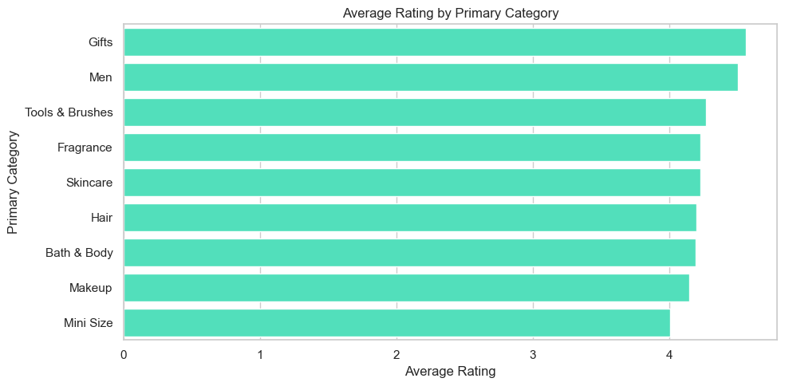

```python
q1 = df.groupby("primary_category")["rating"].mean().sort_values(ascending=False).dropna()
plt.figure(figsize=(10, 5))
sns.barplot(x=q1.values, y=q1.index, color="#3bf6c7")
plt.title("Average Rating by Primary Category")
plt.xlabel("Average Rating")
plt.ylabel("Primary Category")
plt.tight_layout()
plt.show()

top_cat = q1.index[0] if len(q1) else "N/A"
```

### Q2. Among brands with at least N total reviews, which brand_name has the strongest customer satisfaction, based on highest average rating?

We filter to reliable brands and compare average ratings.

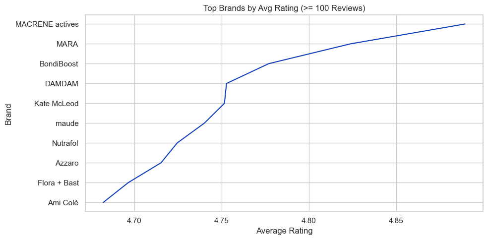

```python
N = 100
brand_stats = df.groupby("brand_name").agg(avg_rating=("rating", "mean"), total_reviews=("reviews", "sum"))
brand_filtered = brand_stats[brand_stats["total_reviews"] >= N].sort_values("avg_rating", ascending=False)
top_brands = brand_filtered.head(10)

plt.figure(figsize=(10, 5))
sns.lineplot(x=top_brands["avg_rating"], y=top_brands.index, color="#103db9")
plt.title(f"Top Brands by Avg Rating (>= {N} Reviews)")
plt.xlabel("Average Rating")
plt.ylabel("Brand")
plt.tight_layout()
plt.show()

top_brand = top_brands.index[0] if len(top_brands) else "N/A"
```

### Q3. What does our product pricing landscape look like overall, and where do most products sit price-wise?

We inspect the price distribution to understand typical price points.

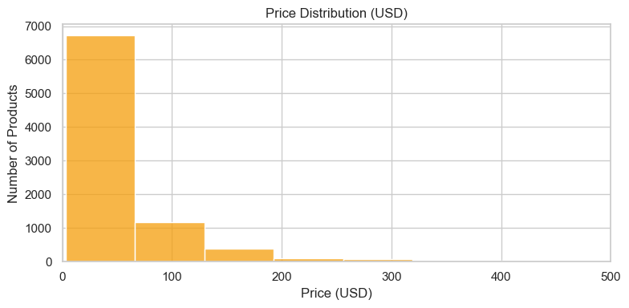

```python
plt.figure(figsize=(8, 4))
sns.histplot(df["price_usd"].dropna(), bins=30, color="#f59e0b")
plt.title("Price Distribution (USD)")
plt.xlabel("Price (USD)")
plt.ylabel("Number of Products")
plt.xlim(0, 500)
plt.tight_layout()
plt.show()

price_median = df["price_usd"].median()
price_p75 = df["price_usd"].quantile(0.75)
```

### Q4. How do average prices differ across product categories, and which categories are positioned as premium vs affordable?

We compare average category prices to identify premium vs affordable groups.

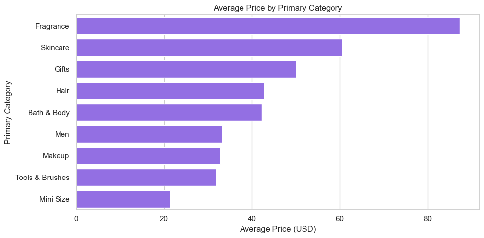

```python
q4 = df.groupby("primary_category")["price_usd"].mean().sort_values(ascending=False).dropna()
plt.figure(figsize=(10, 5))
sns.barplot(x=q4.values, y=q4.index, color="#8b5cf6")
plt.title("Average Price by Primary Category")
plt.xlabel("Average Price (USD)")
plt.ylabel("Primary Category")
plt.tight_layout()
plt.show()

premium_cat = q4.index[0] if len(q4) else "N/A"
affordable_cat = q4.index[-1] if len(q4) else "N/A"
```

### Q5. Is pricing aligned with perceived quality, or are higher-priced products not necessarily rated higher?

We assess the relationship between price and rating with a scatter plot.

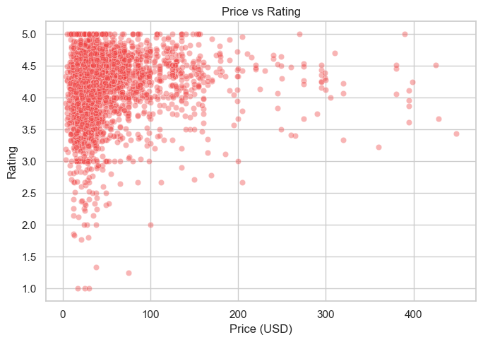

```python
sample = df[["price_usd", "rating"]].dropna()
if len(sample) > 3000:
    sample = sample.sample(3000, random_state=42)

plt.figure(figsize=(7, 5))
sns.scatterplot(data=sample, x="price_usd", y="rating", alpha=0.4, color="#ef4444")
plt.title("Price vs Rating")
plt.xlabel("Price (USD)")
plt.ylabel("Rating")
plt.tight_layout()
plt.show()

corr = sample.corr(numeric_only=True).iloc[0, 1]
```

### Q6. Does higher customer engagement translate into better product satisfaction, or are highly reviewed products rated similarly to others?

We test whether review volume is associated with higher ratings.

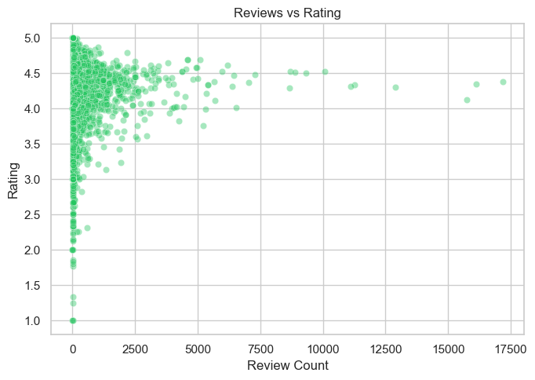

```python
sample = df[["reviews", "rating"]].dropna()
if len(sample) > 3000:
    sample = sample.sample(3000, random_state=42)

plt.figure(figsize=(7, 5))
sns.scatterplot(data=sample, x="reviews", y="rating", alpha=0.4, color="#22c55e")
plt.title("Reviews vs Rating")
plt.xlabel("Review Count")
plt.ylabel("Rating")
plt.tight_layout()
plt.show()

corr = sample.corr(numeric_only=True).iloc[0, 1]
```

### Q7. Which brands drive the most customer interest and demand, based on total loves_count by brand_name?

We rank brands by total loves_count to highlight popularity leaders.

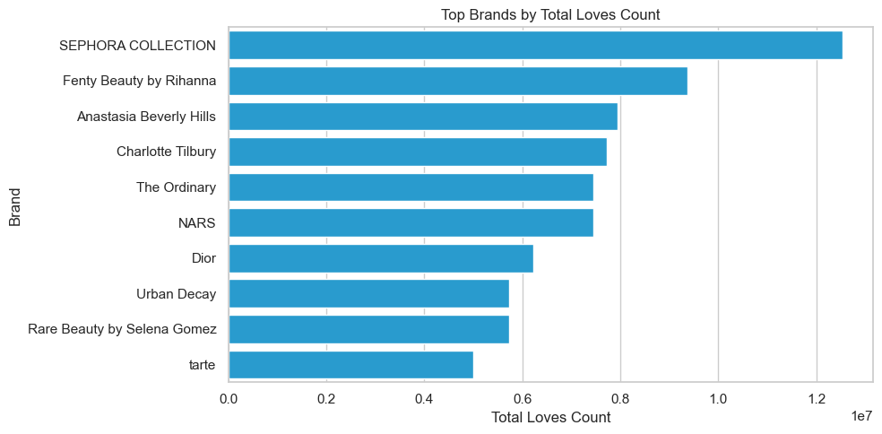

```python
q7 = df.groupby("brand_name")["loves_count"].sum().sort_values(ascending=False).head(10)
plt.figure(figsize=(10, 5))
sns.barplot(x=q7.values, y=q7.index, color="#0ea5e9")
plt.title("Top Brands by Total Loves Count")
plt.xlabel("Total Loves Count")
plt.ylabel("Brand")
plt.tight_layout()
plt.show()

top_pop = q7.index[0] if len(q7) else "N/A"
```

### Q8. Which product categories generate the most customer feedback and activity, based on total reviews by primary_category?

We compare total review volume across categories.

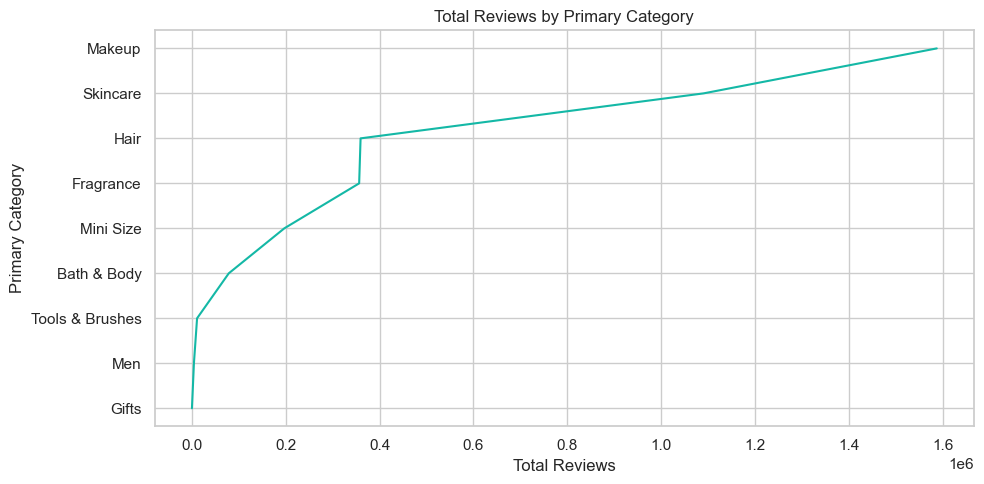

```python
q8 = df.groupby("primary_category")["reviews"].sum().sort_values(ascending=False)
plt.figure(figsize=(10, 5))
sns.lineplot(x=q8.values, y=q8.index, color="#14b8a6")
plt.title("Total Reviews by Primary Category")
plt.xlabel("Total Reviews")
plt.ylabel("Primary Category")
plt.tight_layout()
plt.show()

top_feedback = q8.index[0] if len(q8) else "N/A"
```

### Q9. Does being a sephora_exclusive product impact customer satisfaction compared to non-exclusive products?

We compare ratings between exclusive and non-exclusive products.

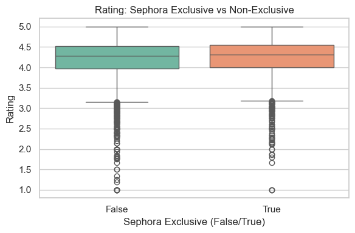

```python
if "is_exclusive" not in df.columns and "sephora_exclusive" in df.columns:
    df["is_exclusive"] = df["sephora_exclusive"].fillna(0).astype(int) == 1

plt.figure(figsize=(6, 4))
sns.boxplot(data=df, x="is_exclusive", y="rating", palette="Set2")
plt.title("Rating: Sephora Exclusive vs Non-Exclusive")
plt.xlabel("Sephora Exclusive (False/True)")
plt.ylabel("Rating")
plt.tight_layout()
plt.show()

excl_mean = df[df["is_exclusive"]]["rating"].mean()
non_mean = df[~df["is_exclusive"]]["rating"].mean()
```

### Q10. Do new products show different pricing and customer satisfaction patterns compared with established products, and what does that imply for new launches?

We compare pricing and ratings for new vs established products.

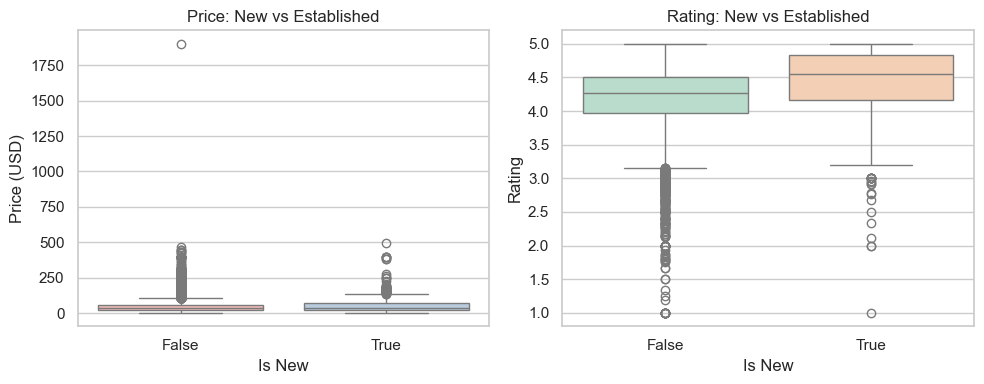

```python
if "is_new" not in df.columns and "new" in df.columns:
    df["is_new"] = df["new"].fillna(0).astype(int) == 1

fig, axes = plt.subplots(1, 2, figsize=(10, 4))
sns.boxplot(data=df, x="is_new", y="price_usd", ax=axes[0], palette="Pastel1")
axes[0].set_title("Price: New vs Established")
axes[0].set_xlabel("Is New")
axes[0].set_ylabel("Price (USD)")

sns.boxplot(data=df, x="is_new", y="rating", ax=axes[1], palette="Pastel2")
axes[1].set_title("Rating: New vs Established")
axes[1].set_xlabel("Is New")
axes[1].set_ylabel("Rating")

plt.tight_layout()
plt.show()

new_price = df[df["is_new"]]["price_usd"].median()
old_price = df[~df["is_new"]]["price_usd"].median()
new_rating = df[df["is_new"]]["rating"].mean()
old_rating = df[~df["is_new"]]["rating"].mean()
```

**Conclusion:** This analysis highlights where customers are most satisfied and engaged, and where pricing strategy can be adjusted to improve perceived value.